CS F364: Design and Analysis of Algorithms

# Divide and Conquer: Maximum Subarray

Lecture 5 |2026-05-21

# Divide and conquer algorithm

- Divide and conquer algorithm

## Maximum subarray problem

## Maximum subarray problem

**Problem Description:** Suppose you are given the price of a stock on each day, and you have to decide when to buy and when to sell to maximize the profit. Note that you cannot sell before you buy.

**Naive strategy:** Try all pairs of (buy, sell) dates, where the buy date must be before the sell date. This takes $\Theta(n^2)$ time.

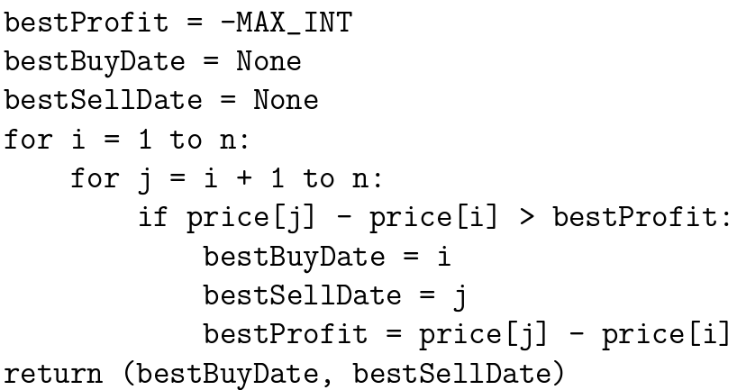

Naive strategy

## Maximum subarray problem

**Divide and conquer strategy:** Instead of daily price, consider the daily change in price, which can be either positive or negative number. Let array $A$ store these changes. Now we have to find the subarray of $A$ that maximizes the sum of the numbers in that subarray.

**Algorithm:** - Divide the array into two. - Find the max subarray in the first half and second half separately. - Find the max subarray crossing the two halves. - Return the max of three.

## Maximum subarray problem

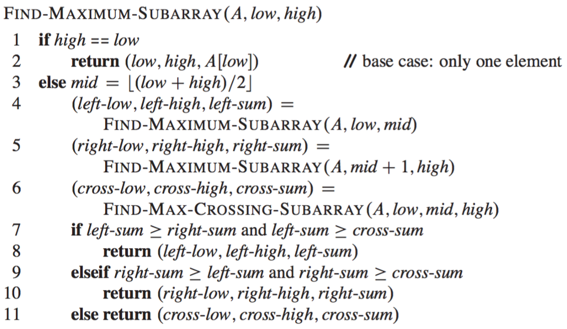

Max subarray algorithm

## Maximum subarray problem

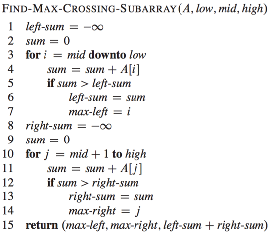

Max crossing subarray

## Closest Pair of Points

## Closest pair of points

Given $n$ points and arbitrary distances between them, find the closest pair. (E.g., think of distance as airfare - This is not Euclidean distance!)

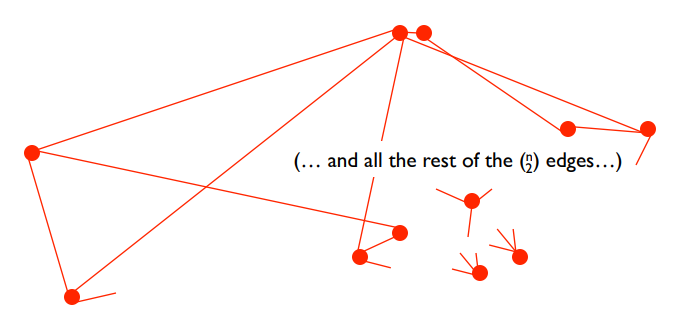

Closest pair example

Must look at all pairwise distances, else any one you didn’t check might be the shortest.

Is this true for Euclidean distance in 1-2 dimensions?

## closest pair of points: 1 dimensional version

Given $n$ points on the real line, find the closest pair.

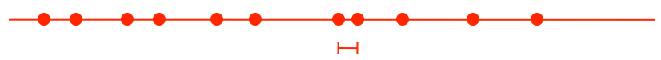

1D Closest Pair

1. Closest pair is adjacent in the ordered list.
2. Time $O(n\log{n})$ to sort, if needed.
3. Plus $O(n)$ to scan adjacent pairs.

**Key point:** do not need to calculate distances between all pairs: exploit geometry + ordering.

## closest pair of points: 2 dimensional version

**Closest pair.** Given $n$ points in the plane, find a pair with smallest Euclidean distance between them.

1. Fundamental geometric primitive.
2. **Applications:** Graphics, computer vision, GIS, molecular modeling etc.

**Brute force.** Check all pairs of points $p$ and $q$ with $\Theta(n^2)$ comparisons.

## closest pair of points: 2D, Euclidean distance - $1^{st}$ try

**Divide:** Sub-divide region into $4$ quadrants.

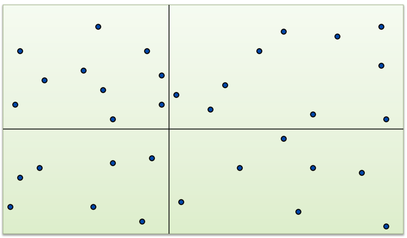

4-quadrant divide

## closest pair of points: 2D, Euclidean distance - $1^{st}$ try

**Divide:** Sub-divide region into $4$ quadrants.  
**Obstacle:** Difficult to ensure $n/4$ points in each quadrant. So, “balanced subdivision” may be problematic.

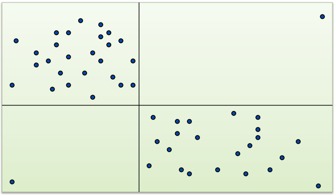

4-quadrant obstacle

## References:

- Michael T. Goodrich and Roberto Tamassia, “Algorithm Design Foundations, Analysis, and Internet Examples”, *Wiley Student Edition*.
- Jon Kleinberg and Eva Tardos, “Algorithm Design”, *Pearson Publishers*.
- Thomas H. Chorman, Charles E. Leiserson, Ronald L. Rivest and Clifford Stein, “Introduction to algorithms”, *MIT Press Publishers*.
- Sanjoy Dasgupta, Umesh Vazirani, Christos Papadimitriou, “Algorithms”, *McGraw-Hill Education Publishers*.